# Summary For Single Sheet

Dennis Wollersheim

12.03.2020

# FILE: P0152_S1-3_combined SHEET: P0152_S1_11-09_snacks_left SHEET_N: 1

## replace outliers with mean of neigbouring points

```r
smoothing_window_width = 500
inflection_window_width = 50
df_in %>%
  mutate(rc_pruned = ifelse( row_n %in%
    findOutliers(df_in$raw_current, n = smoothing_window_width, selectivity = NA, thresholdMin=1, fixedThreshold = TRUE)
,
                              NA, raw_current)) %>%
  mutate( rc_pruned = na.approx( rc_pruned)) %>%
  mutate( rc_loess = loess( rc_pruned ~ unix_time, data=., span=.2 ) %>% predict() )  %>%
  mutate( mean_left  = lag(rollapply(rc_loess, inflection_window_width, mean, align = "right", fill=NA))) %>%
  mutate( mean_right  = lag(rollapply(rc_loess, inflection_window_width, mean, align = "left", fill=NA))) %>%
  mutate( is_max_pt =  replace_na( rc_loess > mean_left & rc_loess > mean_right, FALSE)) %>%
  mutate( is_min_pt =  replace_na( rc_loess < mean_left & rc_loess < mean_right, FALSE)) %>%
  { . } -> df_in_smoothed
```

## raw input data

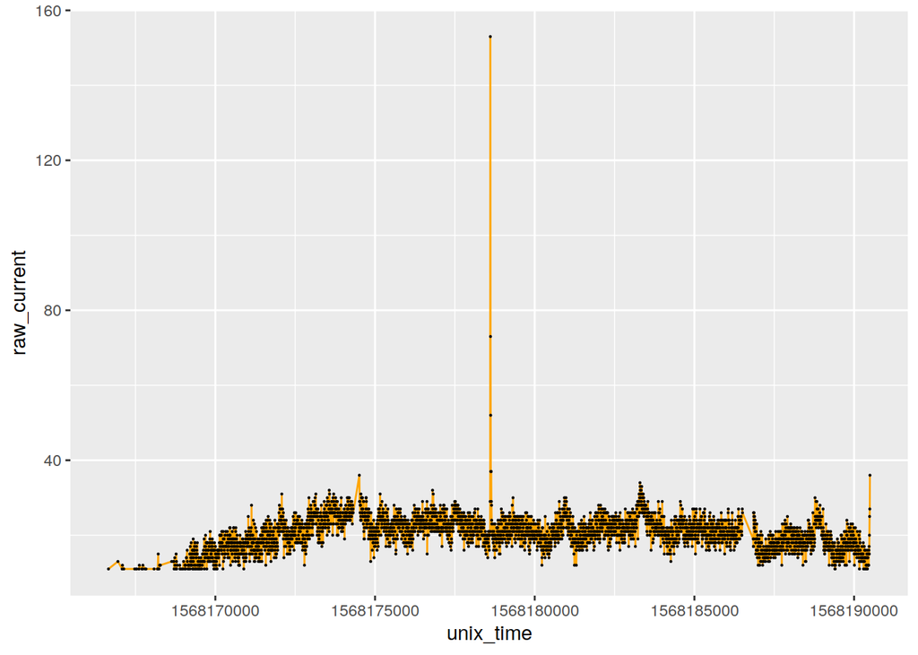

```r
df_in %>%
  ggplot(aes( unix_time, raw_current  )) +
  geom_line( color='orange') +
  geom_point( color='black', size=.1)
```

## smoothed data

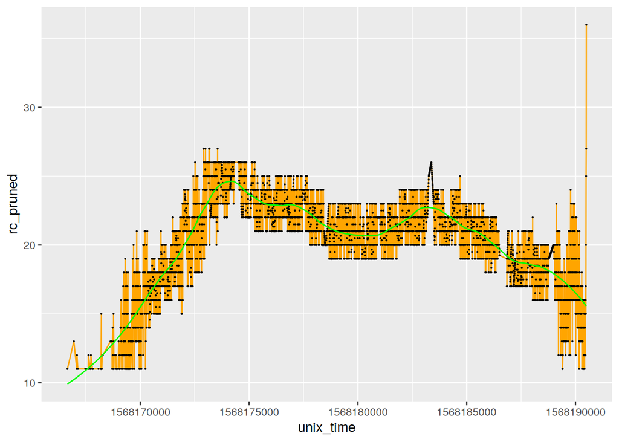

```r
df_in_smoothed %>%
  ggplot(aes( unix_time, rc_pruned  )) +
  geom_line( color='orange') +
  geom_point( color='black', size=.1) +
  geom_line( aes( unix_time, rc_loess ), color='green')
```

## smoothed data with additional cleaning

TODO: Kelly, choose one of these 4 cleaning methods to calculate your AUC values. Currently using the first, no cleaning whatsoever

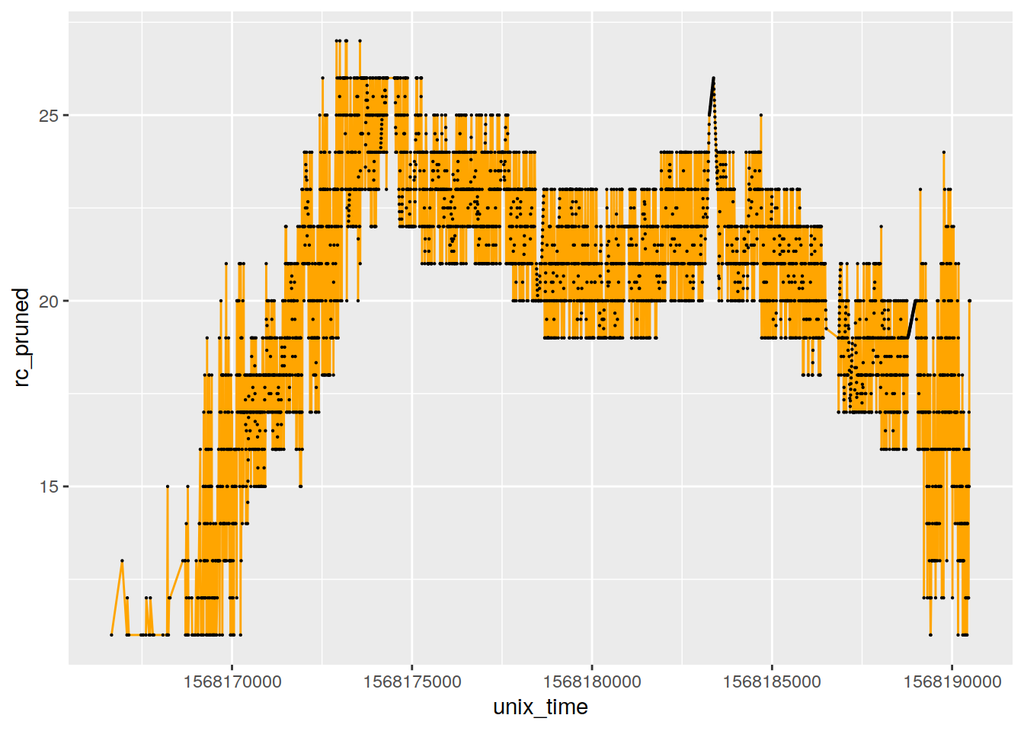

```r
df_in_smoothed %>%
  mutate(rc_pruned = tsclean( rc_pruned)) %>%
  ggplot(aes( unix_time, rc_pruned  )) +
  geom_line( color='orange') +
  geom_point( color='black', size=.1)
```

## calculating important points

- first min,
- first max after first min,
- location of first min after previous max

```r
df_in_smoothed %>%
  mutate( c=chunkify( is_min_pt )) %>%
  filter( c==2 ) %>%
  summarise( min_location = floor(mean( row_n)), min_raw_current = min(rc_pruned)) %>%
  { . } -> tuple_min_location

min_location = tuple_min_location$min_location
min_raw_current = tuple_min_location$min_raw_current

# caculate the last location, and the last raw_current
last_location = length( df_in_smoothed)
last_raw_current = df_in_smoothed %>% pluck('rc_pruned', last_location )



# max_location - the row at the top of the parabola
df_in_smoothed %>%
  filter( row_n > min_location ) %>%
  mutate( c = chunkify( is_max_pt )) %>%
  filter( c==2) %>%
  summarise( max_location = floor(mean( row_n))) %>%
  pluck('max_location') %>%
  { . } -> max_location

df_in_smoothed %>%
  mutate( is_2nd_min =
         (row_n > max_location ) &
         (rc_pruned < min_raw_current ) ) %>%
  pluck('is_2nd_min') %>%
  rle( ) %>%
  pluck(1,1) %>%
  { . } -> min_2nd_location
```

## extract out some subset smoothed chunks for fitting prediction lines

```r
df_in_smoothed %>%
  dplyr::filter( row_n < min_location  ) %>%
  mutate(rc_pruned = tsclean( rc_pruned)) %>%
  { . } -> df_min

df_in_smoothed %>%
  dplyr::filter( row_n  >= min_location  ) %>%
  dplyr::filter( row_n  <=max_location  ) %>%
  mutate(rc_pruned = tsclean( rc_pruned)) %>%
  { . } -> df_max

df_in_smoothed %>%
  dplyr::filter( row_n  >= max_location  ) %>%
  mutate(rc_pruned = tsclean( rc_pruned)) %>%
  { . } -> df_end

df_in_smoothed %>%
  dplyr::filter( row_n  >= min_location  ) %>%
  mutate(rc_pruned = tsclean( rc_pruned)) %>%
  { . } -> df_parabola

# parabola endpoints are the minimum at the left and the first minimum on the right
df_parabola %>%
  filter( row_n > max_location  ) %>%
  filter( rc_pruned == min( rc_pruned)) %>%
  filter( row_n == min( row_n)) %>%
  bind_rows( df_parabola %>% filter( row_n == min( row_n)) ) %>%
  arrange(row_n ) %>%
  select( rc_pruned, unix_time) %>%
  { . } -> df_parabola_endpoints


fit_min = lm( rc_pruned ~ unix_time, data=df_min)
fit_max = lm( rc_pruned ~ unix_time, data=df_max)
fit_end = lm( rc_pruned ~ unix_time, data=df_end)

# straight line between the parabola endpoints
fit_parabola_base = lm( rc_pruned ~ unix_time, data=df_parabola_endpoints)
```

## calculate overall graph parameters to use when generating the new lines

```r
df_in %>%
  summarise( min_ts = min(unix_time),
            max_ts = max( unix_time ),
            n = n(),
            range = max_ts - min_ts,
            step = range / n,
            ) %>%
  { . } -> df_parm
```

## generate the steps along the unix_time scale to generate the new lines

```r
steps_extra = 8000

df_steps_before = tibble( unix_time = df_parm$min_ts - seq( 1:steps_extra ) * df_parm$step,
                row_n = 1- 1:steps_extra
)

df_steps_after = tibble( unix_time = df_parm$max_ts + seq( 1:steps_extra ) * df_parm$step,
                   row_n = df_parm$n+ 1:steps_extra
)

df_in_smoothed %>%
  select( unix_time, row_n) %>%
  rbind( df_steps_before) %>%
  rbind( df_steps_after) %>%
  arrange( row_n ) %>%
  { . } -> df_steps
```

## Predict the lines

```r
df_steps %>%
  mutate( predicted_parabola_base = predict( fit_parabola_base, .)) %>%
  mutate( predicted_min = predict( fit_min, .)) %>%
  mutate( predicted_max = predict( fit_max, .)) %>%
  mutate( predicted_end = predict( fit_end, .)) %>%
  { . } -> df_steps
#df_steps %>% View
df_steps %>% summary()
```

```
   unix_time             row_n       predicted_parabola_base predicted_min
 Min.   :1.568e+09   Min.   :-7999   Min.   :-43.36          Min.   :-62.73
 1st Qu.:1.568e+09   1st Qu.:-3028   1st Qu.:-10.32          1st Qu.:-16.73
 Median :1.568e+09   Median : 1944   Median : 21.56          Median : 30.90
 Mean   :1.568e+09   Mean   : 1944   Mean   : 22.50          Mean   : 29.59
 3rd Qu.:1.568e+09   3rd Qu.: 6916   3rd Qu.: 55.78          3rd Qu.: 75.27
 Max.   :1.568e+09   Max.   :11887   Max.   : 88.82          Max.   :121.27
 predicted_max   predicted_end
 Min.   :22.94   Min.   :-0.1471
 1st Qu.:22.94   1st Qu.:11.1020
 Median :22.94   Median :21.9546
 Mean   :22.94   Mean   :22.2746
 3rd Qu.:22.94   3rd Qu.:33.6025
 Max.   :22.94   Max.   :44.8516
```

## Adjust where parabola_base actually stops (minimum of end, or where it intersects actual raw_current)

```r
# df_in_smoothed %>%
#   inner_join( df_steps, by=c('unix_time', 'row_n')) %>%
#   arrange( row_n ) %>%
#   filter( row_n > min_location ) %>%
#   ggplot(  ) +
#   geom_point(aes( row_n, rc_pruned)) +
#   geom_line( aes( row_n, predicted_parabola_base))

df_in_smoothed %>%
  inner_join( df_steps, by=c('unix_time', 'row_n')) %>%
  arrange( row_n ) %>%
  filter( (row_n > max_location & predicted_parabola_base >= rc_pruned) |
         row_n == max( row_n)) %>%
  filter( row_n == min( row_n )) %>%
  pluck( 'row_n' ) %>%
  { . } -> predicted_parabola_base_end
```

## predict the area under the three predicted base lines (from left to right: min, max and end)

```r
# pull out the AUC size of the triangles

df_steps %>%
  filter( predicted_min > 0 & row_n >= min_location  ) %>%
  summarise( area = trapz( unix_time, predicted_min) ) %>%
  pluck('area') %>%
  { . } -> area_min_triangle

df_steps %>%
  filter( predicted_max > 0 & row_n <= min_location  ) %>%
  summarise( area = trapz( unix_time, predicted_max) ) %>%
  pluck('area') %>%
  { . } -> area_max_triangle


df_steps %>%
  filter( predicted_end > 0 ) %>%
  filter( unix_time >= df_parm$max_ts  ) %>%
  summarise( area = trapz( unix_time, predicted_end) ) %>%
  pluck('area') %>%
  { . } -> area_end_triangle
```

## calculate the main parabola AUC for raw, pruned, loess smoothed and time series cleaned

```r
# the real, raw measurements.  TODO: should smooth this a bit
df_in %>%
  filter( row_n >= min_location  ) %>%
  summarise( area = trapz( unix_time, raw_current) ) %>%
  pluck('area') %>%
  { . } -> area_uc_full_raw

# AUC for smoothed data
df_in_smoothed %>%
  filter( row_n >= min_location  ) %>%
  summarise( area = trapz( unix_time, rc_pruned) ) %>%
  pluck('area') %>%
  { . } -> area_uc_full_smoothed

# AUC for smoothed data loess
df_in_smoothed %>%
  filter( row_n >= min_location  ) %>%
  summarise( area = trapz( unix_time, rc_loess) ) %>%
  pluck('area') %>%
  { . } -> area_uc_full_loess

# AUC for smoothed data cleaned
df_in_smoothed %>%
  filter( row_n >= min_location  ) %>%
  mutate( rc_pruned = tsclean( rc_pruned)) %>%
  summarise( area = trapz( unix_time, rc_pruned) ) %>%
  pluck('area') %>%
  { . } -> area_uc_full_cleaned

# the upper bit of the real raw measurement
df_in_smoothed %>%
  filter( row_n >= min_location  & row_n <= min_2nd_location ) %>%
  summarise( area = trapz( unix_time, rc_pruned) ) %>%
  pluck('area') %>%
  { . } -> area_uc_upper

# to get upper bit, need to subtract the rectangle below
# calculate rectangle height by width
library(magrittr)
df_in_smoothed[ min_2nd_location, 'unix_time'] %>%
  subtract( df_in[ min_location, 'unix_time'] ) %>%
  multiply_by(  min_raw_current  ) %>%
  unlist() %>%
  { . } -> rectangle_area


area_uc_parabola_base = -1
area_uc_parabola = -1
# try( {

  # the upper bit above the parabola base, down to x axis
  df_in_smoothed %>%
    # filter start and end locations along xaxis
    filter( row_n >= min_location & row_n <= predicted_parabola_base_end  ) %>%
    summarise( area = trapz( unix_time, rc_pruned) ) %>%
    pluck('area') %>%
    { . } -> area_uc_parabola

  # below parabola base, down to x axis
    df_steps %>%
      # filter start and end locations along xaxis
      filter( row_n >= min_location & row_n <= predicted_parabola_base_end  ) %>%
      summarise( area = trapz( unix_time, predicted_parabola_base) ) %>%
      pluck('area') %>%
      { . } -> area_uc_parabola_base

  # }, silent=TRUE)

df_auc = tibble(
                raw = area_uc_full_raw,
                smoothed = area_uc_full_smoothed,
                loess = area_uc_full_loess,
                smoothed_and_cleaned = area_uc_full_cleaned
                ) %>%
mutate_all( function(x) { round( x/1000, 0)})





df_rv = tibble(
               max_t = area_max_triangle,
               min_t = area_min_triangle,
               end_t = area_end_triangle,
               full_auc = area_uc_full_raw,
               upper_auc = area_uc_upper - rectangle_area,
               parabola_auc = area_uc_parabola- area_uc_parabola_base
               ) %>%
mutate_all( function(x) { round( x/1000, 0)})
```

## What points were predicted on

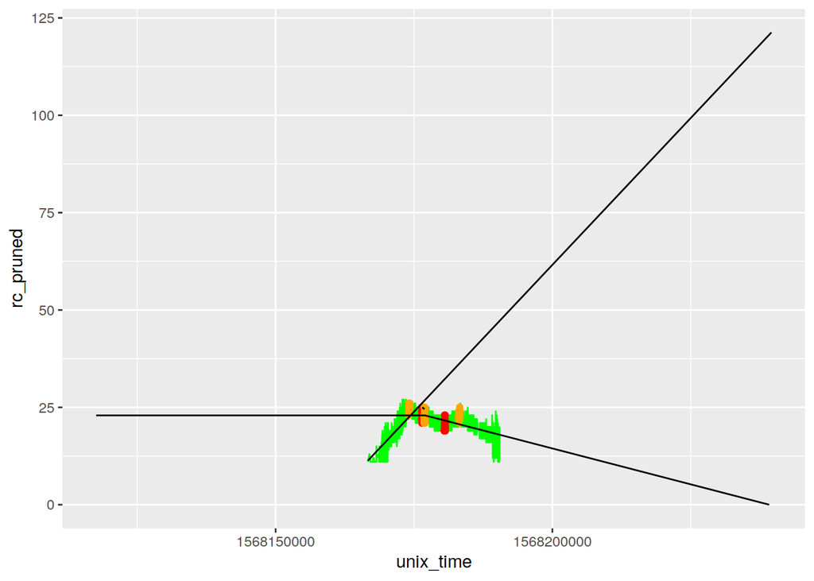

```r
rbind( df_min, df_max ) %>%
  rbind( df_end ) %>%
  ggplot( aes( unix_time, rc_pruned)) +
    geom_line( color='green' ) +
    geom_point( aes( unix_time, rc_pruned), data= . %>% filter( is_min_pt), color='red') +
    geom_point( aes( unix_time, rc_pruned), data= . %>% filter( is_max_pt), color='orange') +
  #  geom_line( aes( unix_time, mean_left ), color='red') +
  geom_line( aes( unix_time, predicted_min), data=(df_steps %>% filter( predicted_min > 0 & row_n > 0  ) )) +
  geom_line( aes( unix_time, predicted_max), data=(df_steps %>% filter( predicted_max > 0 & row_n < max_location ) )) +
  geom_line( aes( unix_time, predicted_end), data=(df_steps %>% filter( predicted_end > 0 & row_n > max_location ) ))  %>%
  { . } -> gg_out

# try ({
  gg_out = gg_out +
  geom_line( aes( unix_time, predicted_parabola_base), data=(df_steps %>% filter( row_n > min_location & row_n < predicted_parabola_base_end ) ))
# }, silent=TRUE)

print(gg_out)
```

## Predicted Areas for the different parts of the graph

- max_t - line from parabola max point, through first minimum. Triangel area is from first minimum to xaxis
- min_t - line from start through first minimum. Triangle area is from first min to xaxis
- end_t - line from parabola max through end. Triangle area is from end to xaxis.
- full_auc - AUC from first min to end
- upper_auc - AUC from first min BAC, to the first timestamp where the min BAC appears after the maximum, subtracting the rectangle under that chunk
- parabola_auc - AUC of the parabola above the diagonal line that runs from first min to the first of either the end, or where that line intersects the BAC measure

The numbers you want are:

- full
- full - min (+end?)
- full+ max (+end?)
- full + end
- upper
- upper_auc

```r
df_rv %>%
  kable(format.args = list(big.mark = ",") ) %>%
  kable_styling(full_width = T)
```

| max_t | min_t | end_t | full_auc | upper_auc | parabola_auc |
| --- | --- | --- | --- | --- | --- |
| 1,351 | 4,649 | 437 | 293 | 2 | -1 |

## Comparision of AUC for the different smoothing methods

The numbers you want are:

```r
df_auc %>%
  kable(format.args = list(big.mark = ",") ) %>%
  kable_styling(full_width = T)
```

| raw | smoothed | loess | smoothed_and_cleaned |
| --- | --- | --- | --- |
| 293 | 288 | 288 | 288 |

```r
tibble( base_file=params$base_file, sheet_n=params$sheet_n) %>%
  bind_cols( df_rv ) %>%
  bind_cols( df_auc ) %>%
  write_csv( output_csv )
```